# Random Walk

R. G. Cronce

9/10/2020

## Random Walk Simulation

[R-bloggers article on Random Walks](https://www.r-bloggers.com/simulating-paths-from-a-random-walk)

A random walk is established based on a walk of +/- 1 with a probability of p, 1-p until the walk exceeds an upper or lower limit. The semi-interesting part of the simulation is that when p differs from 0.5 (even by a small amount), the walk terminates positive or negative with a very high skew. A closed form solution for the expected result is included at the website.

BTW it was very nice to read an article that didn’t require the tidyverse and 8 million additional packages just to play with a nice simple problem!

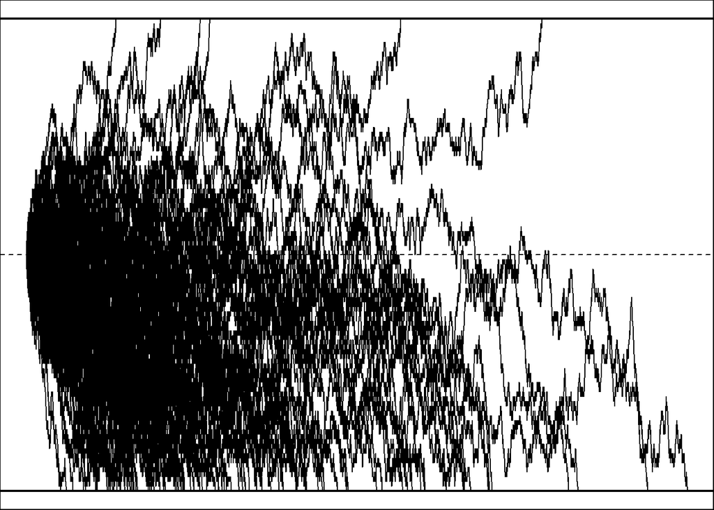

```r
# returns the random walk path values as a vector
# (random walk always starts at 0)
# p: probability of increasing by 1
# stop if path value hits either `lower` or `upper`
run <- function(p, lower, upper) {
    values <- c(0)
    current <- 0
    while (current > lower & current < upper) {
        current <- current + ifelse(runif(1) < p, 1, -1)
        values <- c(values, current)
    }
    values
}

N <- 100  # no. of paths to simulate
p <- 0.48
lower <- -50
upper <- 50

# simulate paths
set.seed(1055)
# set.seed(2020)
vlist <- replicate(N, run(p, lower, upper))

# get length of longest path
max_length <- max(sapply(vlist, length))

# make plot
par(mar = rep(0, 4))  # no margins
plot(c(1, max_length), c(lower, upper), type = "n")
for (i in 1:N) {
    lines(1:length(vlist[[i]]), vlist[[i]])
}
abline(h = 0, lty = "dashed")
abline(h = lower, lwd = 2)
abline(h = upper, lwd = 2)
```

## Adding colors

The plot above is difficult to interpret. It would be better to color all the paths that terminate positive in one color and all the paths that terminate negative in another. This is shown below:

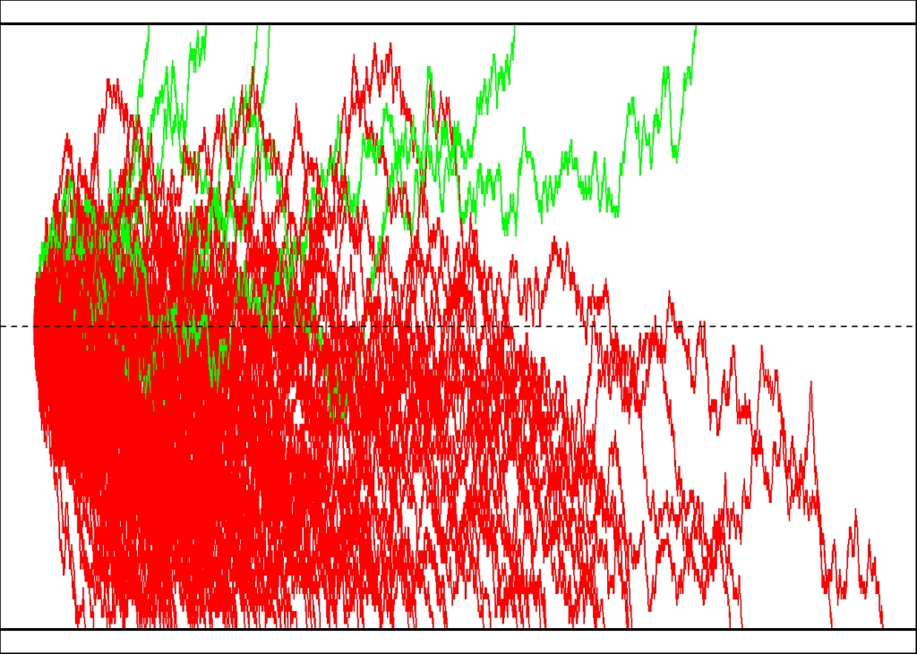

```r
par(mar = rep(0, 4))  # no margins
plot(c(1, max_length), c(lower, upper), type = "n")
for (i in 1:N) {
    l = length(vlist[[i]])
    if (vlist[[i]][l]>0) { lcolor='green' } else { lcolor='red' }
    lines(1:length(vlist[[i]]), vlist[[i]],col=lcolor)
}
abline(h = 0, lty = "dashed")
abline(h = lower, lwd = 2)
abline(h = upper, lwd = 2)
```

## Adding shades of color

The code from the Website actually adjusts the color of the plot based on the direction of the path and the length of the path (compared to the maximum length path).

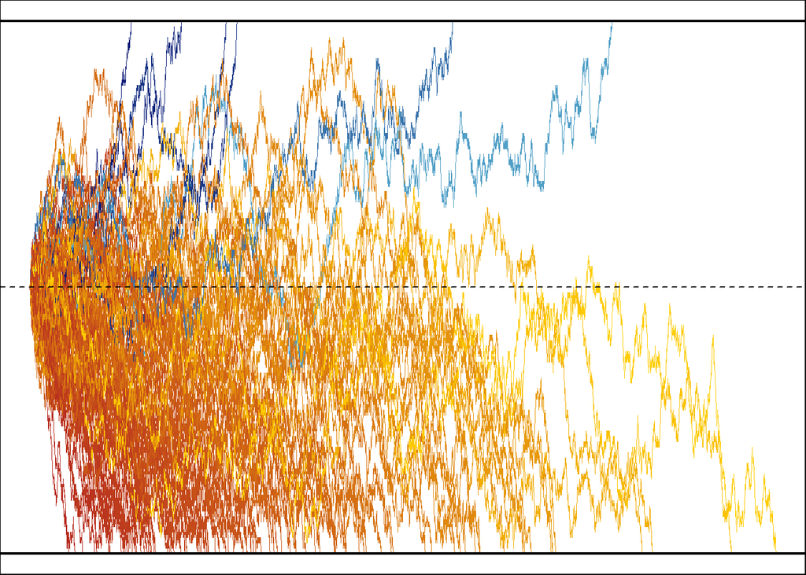

```r
# Note that I modified the code to use path_length instead of the single character
# variable name, l, used on the website since I misread lower case l as digit 1 when
# I was reading the code.  Never, ever use lower case l as a variable!!!
#
# Paths heading toward the lower limit will vary in color from ls_color to ll_color
# as the path gets longer.  Paths heading toward the uppper limit will vary from
# us_color to ul_color as the path gets longer.

colorPicker <- function(values, max_length,
                        ls_color = c(178, 34, 34), ll_color = c(255, 204, 0),
                        us_color = c(0, 0, 102), ul_color = c(102, 204, 225)) {
    path_length <- length(values)
    if (values[path_length] < 0) {
        rgb_values <- (ls_color + (ll_color - ls_color) * path_length / max_length) / 255
    } else {
        rgb_values <- (us_color + (ul_color - us_color) * path_length / max_length) / 255
    }
    rgb(rgb_values[1], rgb_values[2], rgb_values[3])
}

par(mar = rep(0, 4))  # no margins
plot(c(1, max_length), c(lower, upper), type = "n")
for (i in 1:N) {
    lines(1:length(vlist[[i]]), vlist[[i]],
          col = colorPicker(vlist[[i]], max_length), lwd = 0.5)
}

abline(h = 0, lty = "dashed")
abline(h = lower, lwd = 2)
abline(h = upper, lwd = 2)
```

## End of the Report

QED